# EDA ON WALMART DATASET

TEAM PROJECT

2022-10-02

## R Markdown

```r
library(readxl)
library(RColorBrewer)
library(ggplot2)
getwd()
```

```
## [1] "C:/Users/anjal/OneDrive/Desktop/PROJECTS"
```

```r
data = read_excel("Walmart Retail Dataset.xlsx")
View(data)
str(data)
```

```
## tibble [8,399 x 25] (S3: tbl_df/tbl/data.frame)
##  $ City                : chr [1:8399] "McKeesport" "Bowie" "Napa" "Montebello" ...
##  $ Customer Age        : num [1:8399] NA NA NA NA NA NA NA NA NA NA ...
##  $ Customer Name       : chr [1:8399] "Jessica Myrick" "Matt Collister" "Alan Schoenberger" "Elizabeth Moffitt" ...
##  $ Customer Segment    : chr [1:8399] "Small Business" "Home Office" "Corporate" "Consumer" ...
##  $ Discount            : num [1:8399] 0.1 0.08 0 0.08 0.07 0.09 0.06 0.05 0.09 0.05 ...
##  $ Number of Records   : num [1:8399] 1 1 1 1 1 1 1 1 1 1 ...
##  $ Order Date          : POSIXct[1:8399], format: "2012-01-01" "2012-01-01" ...
##  $ Order ID            : num [1:8399] 28774 13729 37537 44069 37537 ...
##  $ Order Priority      : chr [1:8399] "High" "Not Specified" "Low" "Critical" ...
##  $ Order Quantity      : num [1:8399] 32 9 4 43 43 16 3 32 4 12 ...
##  $ Product Base Margin : num [1:8399] 0.68 NA 0.56 0.39 0.69 0.4 0.36 0.59 0.64 0.78 ...
##  $ Product Category    : chr [1:8399] "Office Supplies" "Office Supplies" "Furniture" "Office Supplies" ...
##  $ Product Container   : chr [1:8399] "Small Box" "Large Box" "Jumbo Drum" "Wrap Bag" ...
##  $ Product Name        : chr [1:8399] "Perma STOR-ALL\231 Hanging File Box, 13 1/8\"W x 12 1/4\"D x 10 1/2\"H" "Safco Industrial Wire Shelving" "Hon 4070 Series Pagoda\231 Armless Upholstered Stacking Chairs" "White GlueTop Scratch Pads" ...
##  $ Product Sub-Category: chr [1:8399] "Storage & Organization" "Storage & Organization" "Chairs & Chairmats" "Paper" ...
##  $ Profit              : num [1:8399] -112 -343 -193 248 -1050 ...
##  $ Region              : chr [1:8399] "East" "East" "West" "West" ...
##  $ Row ID              : num [1:8399] 4031 1914 5272 6225 5273 ...
##  $ Sales               : num [1:8399] 180 872 1239 615 4083 ...
##  $ Ship Date           : POSIXct[1:8399], format: "2012-01-02" "2012-01-03" ...
##  $ Ship Mode           : chr [1:8399] "Regular Air" "Express Air" "Delivery Truck" "Regular Air" ...
##  $ Shipping Cost       : num [1:8399] 4.69 35 48.8 1.97 45 2.15 2.99 7.07 52.2 21.2 ...
##  $ State               : chr [1:8399] "Pennsylvania" "Maryland" "California" "California" ...
##  $ Unit Price          : num [1:8399] 5.98 95.99 291.73 15.04 100.98 ...
##  $ Zip Code            : num [1:8399] 15131 20715 94559 90640 94559 ...
```

```r
head(data)
```

```
## # A tibble: 6 x 25
##   City       Custo~1 Custo~2 Custo~3 Disco~4 Numbe~5 `Order Date`        Order~6
##   <chr>        <dbl> <chr>   <chr>     <dbl>   <dbl> <dttm>                <dbl>
## 1 McKeesport      NA Jessic~ Small ~    0.1        1 2012-01-01 00:00:00   28774
## 2 Bowie           NA Matt C~ Home O~    0.08       1 2012-01-01 00:00:00   13729
## 3 Napa            NA Alan S~ Corpor~    0          1 2012-01-02 00:00:00   37537
## 4 Montebello      NA Elizab~ Consum~    0.08       1 2012-01-02 00:00:00   44069
## 5 Napa            NA Alan S~ Corpor~    0.07       1 2012-01-02 00:00:00   37537
## 6 Montebello      NA Elizab~ Consum~    0.09       1 2012-01-02 00:00:00   44069
## # ... with 17 more variables: `Order Priority` <chr>, `Order Quantity` <dbl>,
## #   `Product Base Margin` <dbl>, `Product Category` <chr>,
## #   `Product Container` <chr>, `Product Name` <chr>,
## #   `Product Sub-Category` <chr>, Profit <dbl>, Region <chr>, `Row ID` <dbl>,
## #   Sales <dbl>, `Ship Date` <dttm>, `Ship Mode` <chr>, `Shipping Cost` <dbl>,
## #   State <chr>, `Unit Price` <dbl>, `Zip Code` <dbl>, and abbreviated variable
## #   names 1: `Customer Age`, 2: `Customer Name`, 3: `Customer Segment`, ...
## # i Use `colnames()` to see all variable names
```

```r
data$`Customer Age`[is.na(data$`Customer Age`)]= mean(data$`Customer Age`,na.rm = T)
data$`Product Base Margin`[is.na(data$`Product Base Margin`)]=mean(data$`Product Base Margin`,na.rm = T)
View(data)
```

## CUSTOMER SEGMENT

```r
CS_OP =table(data$`Customer Segment`,data$`Order Priority`)
summary(CS_OP)
```

```
## Number of cases in table: 8399
## Number of factors: 2
## Test for independence of all factors:
##  Chisq = 10.855, df = 12, p-value = 0.5414
```

```r
CS_PSC = table(data$`Customer Segment`,data$`Product Sub-Category`)
summary(CS_PSC)
```

```
## Number of cases in table: 8399
## Number of factors: 2
## Test for independence of all factors:
##  Chisq = 33.6, df = 48, p-value = 0.9429
```

```r
CS_PSC
```

```
##
##                  Appliances Binders and Binder Accessories Bookcases
##   Consumer               73                            172        42
##   Corporate             179                            343        63
##   Home Office           104                            229        43
##   Small Business         78                            171        41
##
##                  Chairs & Chairmats Computer Peripherals Copiers and Fax
##   Consumer                       79                  154              17
##   Corporate                     149                  276              31
##   Home Office                    87                  182              19
##   Small Business                 71                  146              20
##
##                  Envelopes Labels Office Furnishings Office Machines Paper
##   Consumer              42     61                157              74   234
##   Corporate             89    103                292             127   428
##   Home Office           52     71                190              75   310
##   Small Business        63     53                149              61   253
##
##                  Pens & Art Supplies Rubber Bands Scissors, Rulers and Trimmers
##   Consumer                       121           29                            28
##   Corporate                      237           61                            56
##   Home Office                    150           45                            39
##   Small Business                 125           44                            21
##
##                  Storage & Organization Tables Telephones and Communication
##   Consumer                          105     80                          181
##   Corporate                         184    129                          329
##   Home Office                       145     86                          205
##   Small Business                    112     66                          168
```

```r
CS_PC = table(data$`Customer Segment`,data$`Product Category`)
summary(CS_PC)
```

```
## Number of cases in table: 8399
## Number of factors: 2
## Test for independence of all factors:
##  Chisq = 6.705, df = 6, p-value = 0.349
```

```r
CS_SM = table(data$`Customer Segment`,data$`Ship Mode`)
summary(CS_SM)
```

```
## Number of cases in table: 8399
## Number of factors: 2
## Test for independence of all factors:
##  Chisq = 0.9347, df = 6, p-value = 0.988
```

```r
CS_REGION = table(data$`Customer Segment`,data$Region)
summary(CS_REGION)
```

```
## Number of cases in table: 8399
## Number of factors: 2
## Test for independence of all factors:
##  Chisq = 120.86, df = 9, p-value = 8.921e-22
```

## ORDER_PRIORITY

```r
OP_PC = table(data$`Order Priority`,data$`Product Category`)
summary(OP_PC)
```

```
## Number of cases in table: 8399
## Number of factors: 2
## Test for independence of all factors:
##  Chisq = 7.764, df = 8, p-value = 0.4569
```

```r
OP_PCon = table(data$`Order Priority`,data$`Product Container`)
summary(OP_PCon)
```

```
## Number of cases in table: 8399
## Number of factors: 2
## Test for independence of all factors:
##  Chisq = 24.965, df = 24, p-value = 0.4077
```

```r
OP_PSC = table(data$`Order Priority`,data$`Product Sub-Category`)
summary(OP_PSC)
```

```
## Number of cases in table: 8399
## Number of factors: 2
## Test for independence of all factors:
##  Chisq = 58.28, df = 64, p-value = 0.6781
```

```r
OP_SM = table(data$`Order Priority`,data$`Ship Mode`)
summary(OP_SM)
```

```
## Number of cases in table: 8399
## Number of factors: 2
## Test for independence of all factors:
##  Chisq = 8.134, df = 8, p-value = 0.4205
```

```r
OP_REGION = table(data$`Order Priority`,data$Region)
summary(OP_REGION)
```

```
## Number of cases in table: 8399
## Number of factors: 2
## Test for independence of all factors:
##  Chisq = 12.222, df = 12, p-value = 0.428
```

**Inference drawn is that all the fields are independent.**

## PRODUCT CATEGORY

```r
PC_PCon = table(data$`Product Category`,data$`Product Container`)
summary(PC_PCon)
```

```
## Number of cases in table: 8399
## Number of factors: 2
## Test for independence of all factors:
##  Chisq = 4062, df = 12, p-value = 0
```

```r
PC_PSC = table(data$`Product Category`,data$`Product Sub-Category`)
summary(PC_PSC)
```

```
## Number of cases in table: 8399
## Number of factors: 2
## Test for independence of all factors:
##  Chisq = 16798, df = 32, p-value = 0
```

```r
PC_SM = table(data$`Product Category`,data$`Ship Mode`)
summary(PC_SM)
```

```
## Number of cases in table: 8399
## Number of factors: 2
## Test for independence of all factors:
##  Chisq = 2456, df = 4, p-value = 0
```

```r
PC_REGION = table(data$`Product Category`,data$Region)
summary(PC_REGION)
```

```
## Number of cases in table: 8399
## Number of factors: 2
## Test for independence of all factors:
##  Chisq = 12.246, df = 6, p-value = 0.05669
```

**Inference : The first three variables are dependent while region is independent of field product category.**

## PRODUCT CONTAINER

```r
PCON_PSC = table(data$`Product Container`,data$`Product Sub-Category`)
summary(PCON_PSC)
```

```
## Number of cases in table: 8399
## Number of factors: 2
## Test for independence of all factors:
##  Chisq = 21610, df = 96, p-value = 0
##  Chi-squared approximation may be incorrect
```

```r
PCON_REGION = table(data$`Product Container`,data$Region)
summary(PCON_REGION)
```

```
## Number of cases in table: 8399
## Number of factors: 2
## Test for independence of all factors:
##  Chisq = 44.06, df = 18, p-value = 0.000566
```

```r
PCON_SM = table(data$`Product Container`,data$`Ship Mode`)
summary(PCON_SM)
```

```
## Number of cases in table: 8399
## Number of factors: 2
## Test for independence of all factors:
##  Chisq = 8318, df = 12, p-value = 0
```

**Inference : Fields are dependent of each other.**

## PRODUCT SUB-CATEGORY

```r
PSC_REGION = table(data$`Product Sub-Category`,data$Region)
summary(PSC_REGION)
```

```
## Number of cases in table: 8399
## Number of factors: 2
## Test for independence of all factors:
##  Chisq = 89.61, df = 48, p-value = 0.000254
```

```r
PSC_SM = table(data$`Product Sub-Category`,data$`Ship Mode`)
summary(PSC_SM)
```

```
## Number of cases in table: 8399
## Number of factors: 2
## Test for independence of all factors:
##  Chisq = 6300, df = 32, p-value = 0
```

```r
SM_REGION = table(data$`Ship Mode`,data$Region)
summary(SM_REGION)
```

```
## Number of cases in table: 8399
## Number of factors: 2
## Test for independence of all factors:
##  Chisq = 8.001, df = 6, p-value = 0.2381
```

## SALES

```r
cor(data$Sales,data$Discount)
```

```
## [1] -0.01968634
```

```r
cor(data$Sales,data$`Order Quantity`)
```

```
## [1] 0.2205819
```

```r
cor(data$Sales,data$Profit)
```

```
## [1] 0.5819603
```

```r
cor(data$Sales,data$`Shipping Cost`)
```

```
## [1] 0.4345783
```

```r
cor(data$Sales,data$`Product Base Margin`)
```

```
## [1] 0.1557944
```

## PROFIT

```r
cor(data$Profit,data$Discount)
```

```
## [1] -0.03712837
```

```r
cor(data$Profit,data$Sales)
```

```
## [1] 0.5819603
```

```r
cor(data$Profit,data$`Shipping Cost`)
```

```
## [1] -0.02136219
```

**Inference : Sales and Profit are dependent on each other.**

## ORDER QUANTITY

```r
cor(data$`Order Quantity`,data$Discount)
```

```
## [1] -0.009648944
```

```r
cor(data$`Order Quantity`,data$Profit)
```

```
## [1] 0.1946552
```

```r
cor(data$`Order Quantity`,data$Sales)
```

```
## [1] 0.2205819
```

```r
cor(data$`Order Quantity`,data$`Shipping Cost`)
```

```
## [1] -0.01145708
```

**Inference : Profit and Sales are dependent on Order Quantity.**

## DATA VISUALIZATION

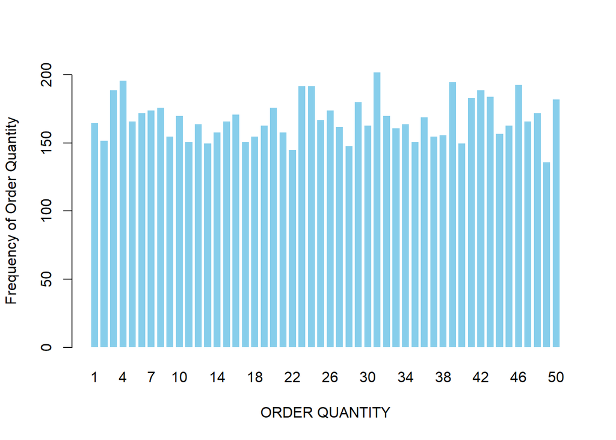

```r
barplot(table(data$`Order Quantity`),col = "SKYBLUE",border = "WHITE",xlab = "ORDER QUANTITY",ylab = "Frequency of Order Quantity")
```

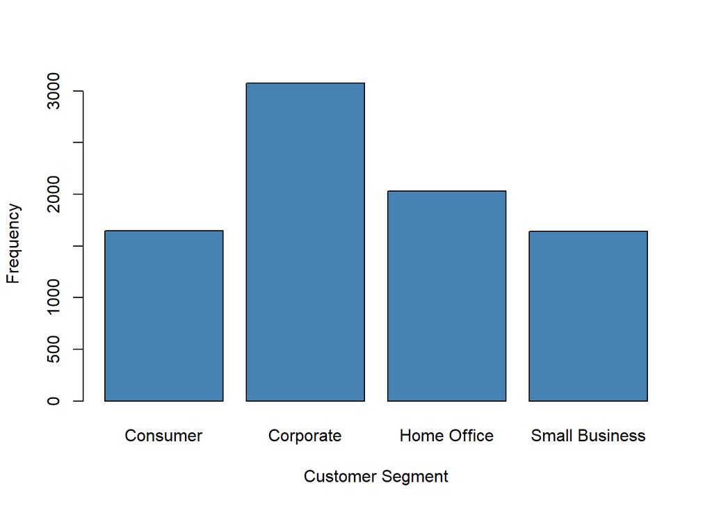

```r
barplot(table(data$`Customer Segment`),col = "steelblue",border = "black",xlab = "Customer Segment",ylab = "Frequency")
```

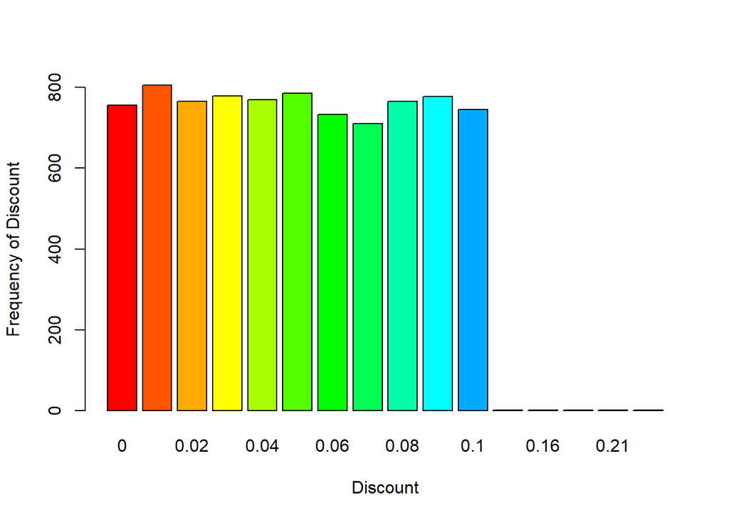

```r
barplot(table(data$Discount),col = rainbow(18),xlab = "Discount",ylab = "Frequency of Discount")
```

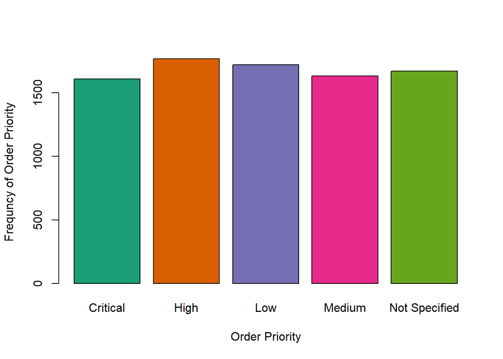

```r
barplot(table(data$`Order Priority`),col = brewer.pal(5,"Dark2"),xlab = "Order Priority",ylab = "Frequncy of Order Priority")
```

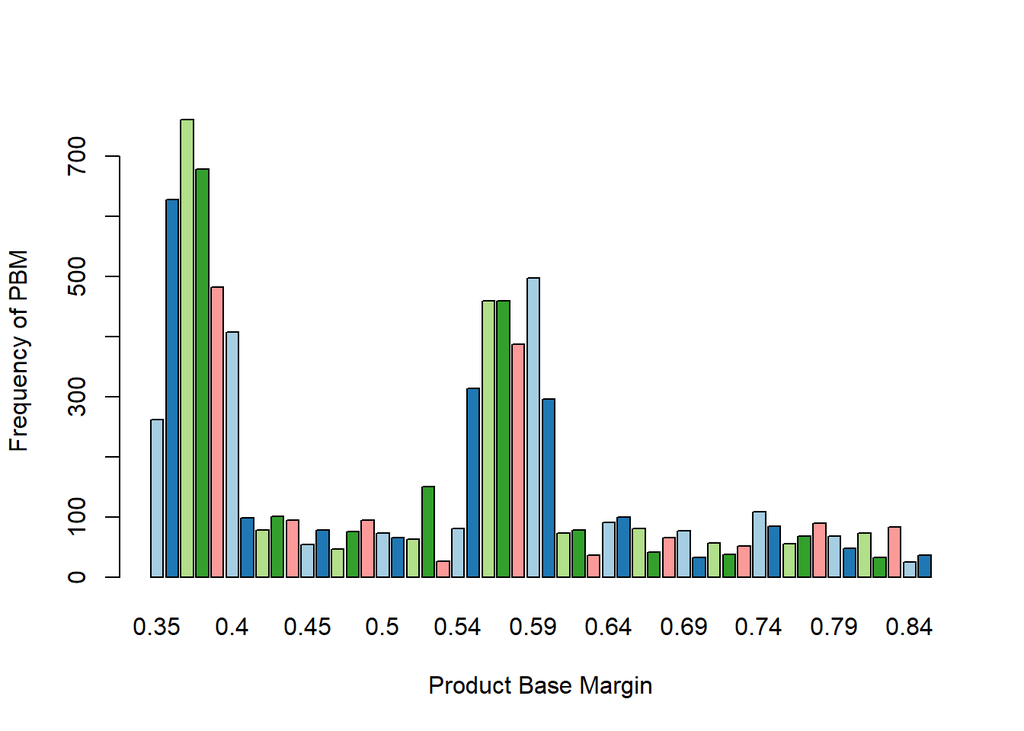

```r
barplot(table(data$`Product Base Margin`),col=brewer.pal(5,"Paired"),xlab = "Product Base Margin",ylab = "Frequency of PBM")
```

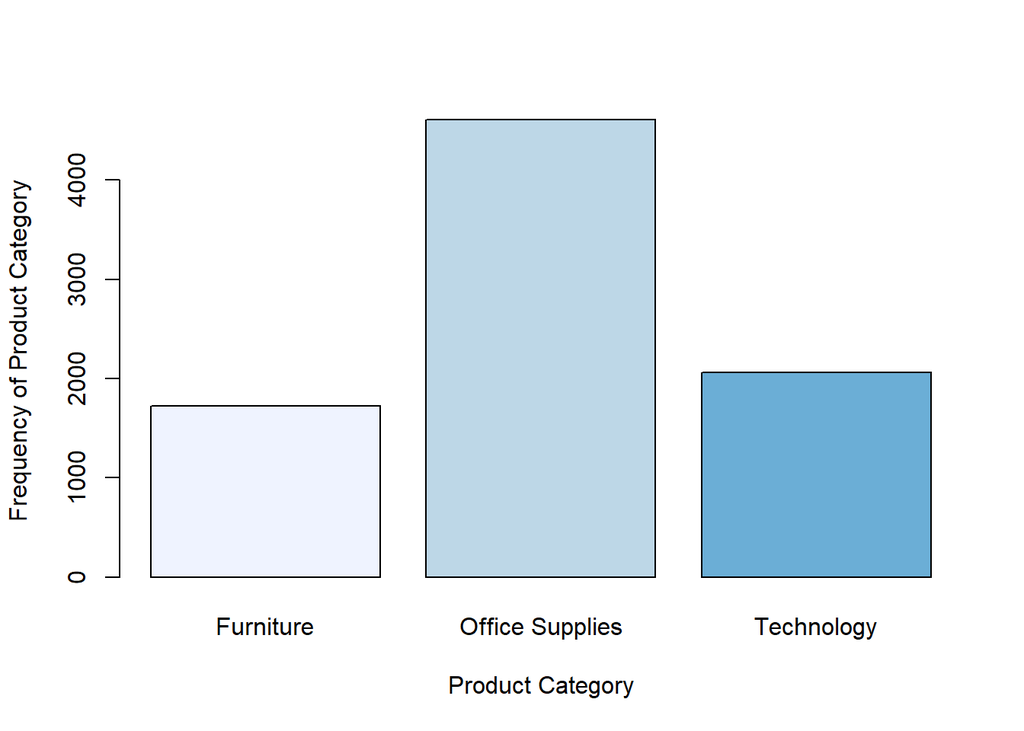

```r
barplot(table(data$`Product Category`),col = brewer.pal(5,"Blues"),xlab = "Product Category",ylab = "Frequency of Product Category")
```

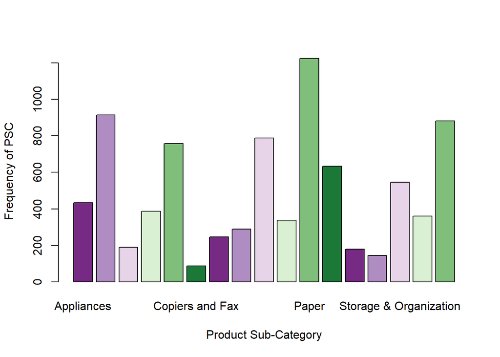

```r
barplot(table(data$`Product Sub-Category`),col = brewer.pal(6,"PRGn"),xlab = "Product Sub-Category",ylab = "Frequency of PSC")
```

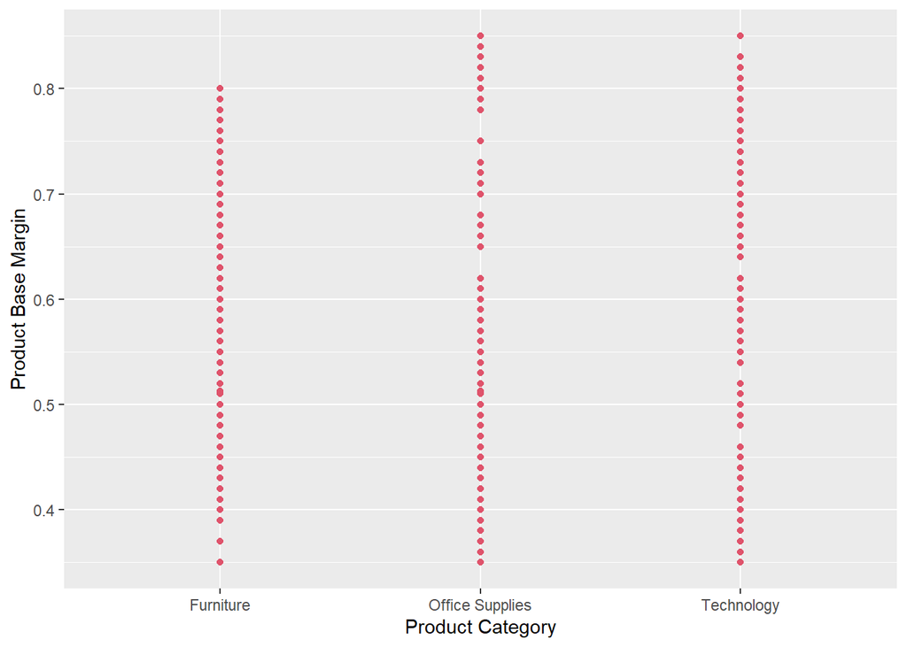

```r
ggplot(data = data,aes(y = `Product Base Margin`,x = `Product Category`))+geom_point(col=2)
```

**Inference : Product Base Margin for the office supplies is higher followed by Technology and Furniture.**

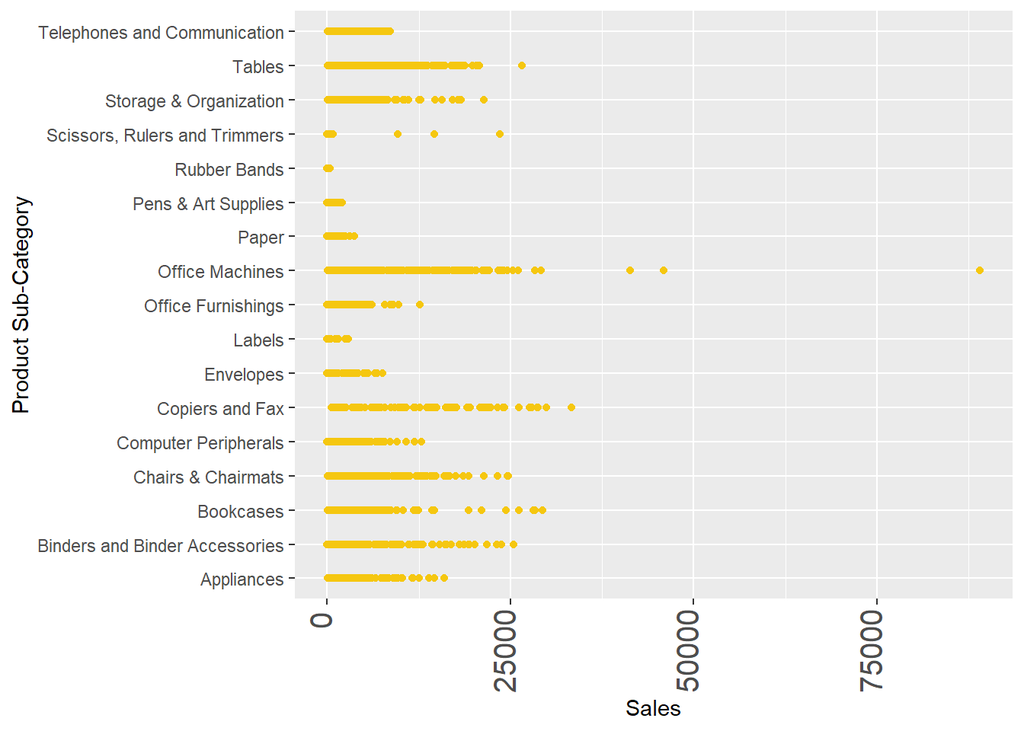

```r
ggplot(data = data,aes(y = `Sales`,x = `Product Sub-Category`))+geom_point(col=7)+
theme(axis.text.x=element_text(size=15, angle=90,hjust=0.95,vjust=0.2))+
  coord_flip()
```

**Inference : Sales for Office Machines is higher which lies under office supplies category followed by Copiers and Fax, Bookcases and so on.**

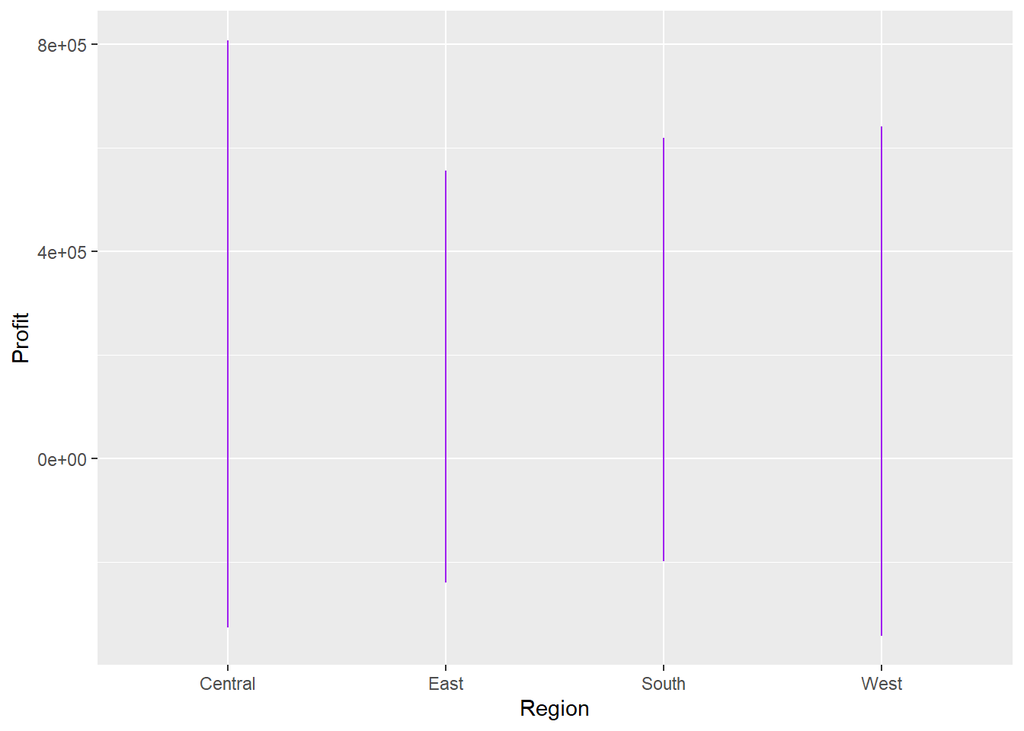

```r
ggplot(data = data,aes(y = `Profit`,x =`Region`))+ geom_area(col="purple")
```

**Inference : Central region has the highest profit followed by west, south and east.**

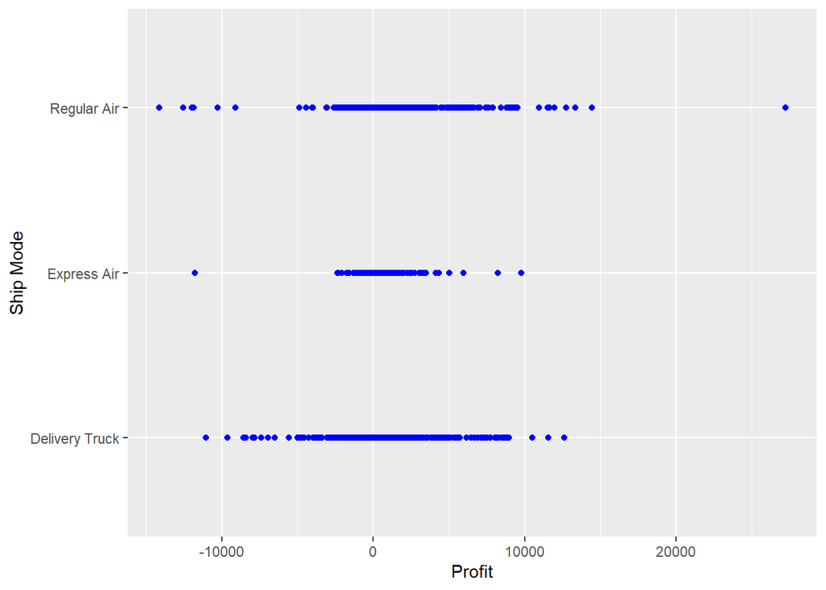

```r
ggplot(data = data,aes(y = `Profit`,x = `Ship Mode`))+geom_point(col="blue")+coord_flip()
```

**Inference : Profit for the Regular Air is higher followed by Delivery truck and Express air.**

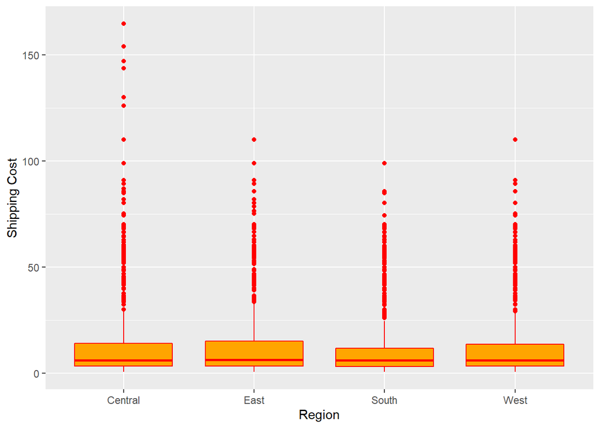

```r
ggplot(data = data,aes(y = `Shipping Cost`,x = `Region`))+ geom_boxplot(fill="orange",col="red")
```

**Inference : For central region shippinmg cost is higher whereas for the south region it is lowest.**

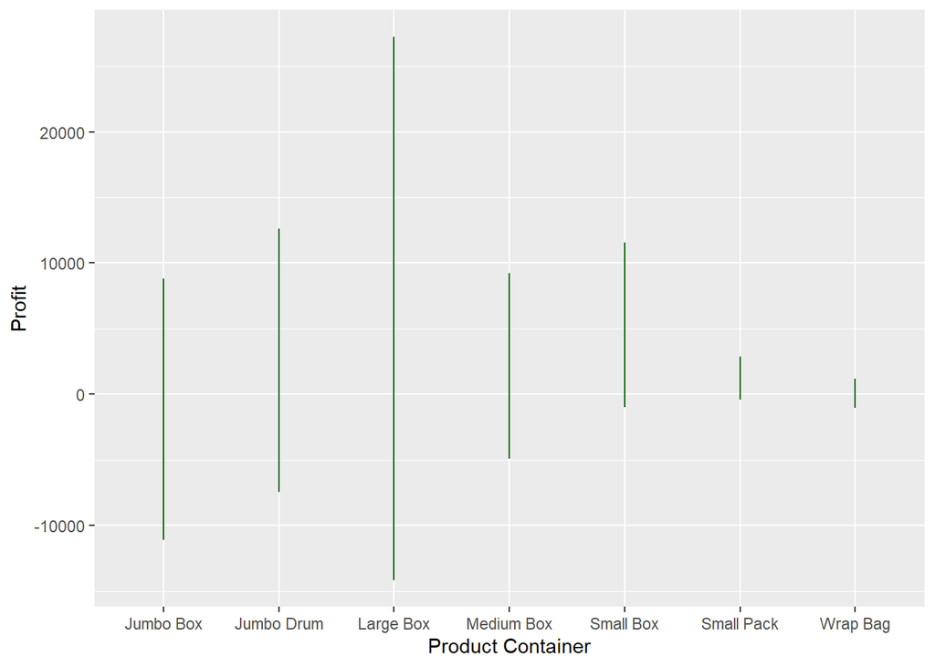

```r
ggplot(data = data,aes(y = `Profit`,x = `Product Container`))+geom_polygon(col = "darkgreen")
```

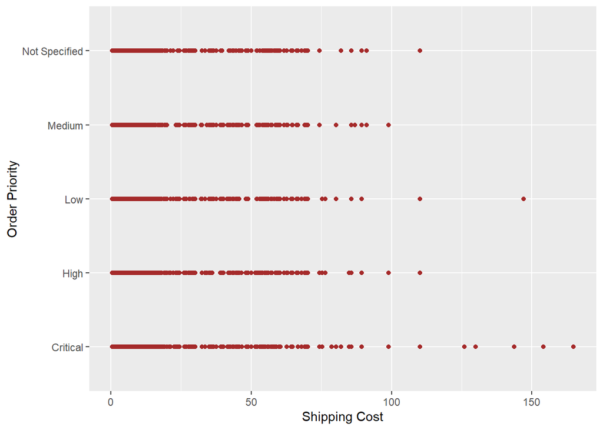

```r
ggplot(data = data,aes(y = `Shipping Cost`,x = `Order Priority`))+geom_point(col="brown")+
  coord_flip()
```

**Inference : As per the Order priority the shipping cost also varies, it is highest for critical and lowest for medium.**